# Final Project

Ryan Scehovic

4/22/2021

```r
suppressWarnings(library(dplyr))
suppressWarnings(library(data.table))
```

```r
suppressWarnings(library(ggplot2))
suppressWarnings(library(tidyverse))
data2 <- read_csv('genderAndAgeData.csv')
data2 <- na.omit(data2)
data2 <- data2 %>% rename(fatals = 'Fatalities in crash')

f1 <- data2 %>% group_by(Age, Gender) %>% summarize(count = n()) %>% arrange(desc(count))
```

## Accidents Given Age

Younger people in general got in a lot more accidents. This is likely due to lack of experience and getting distracted while driving. Common distractions are phones and friends in the car, so teenagers and young adults learning to balance that while driving can be challenging.

The biggest drop offs are in the late 20’s to early 40’s. This could be due to maturing and becoming more responsible drivers over time. There is also a drop off at 60 and 75 years old which is likely due people driving less as they get older and retire.

I was interested in some of these numbers so I did some research and found that on average men drive 40% more miles per year than women, which would explain the general idea that men get in more accidents, but to see 2-3 times more accidents means there are still other factors playing a major role in why men get into more accidents.

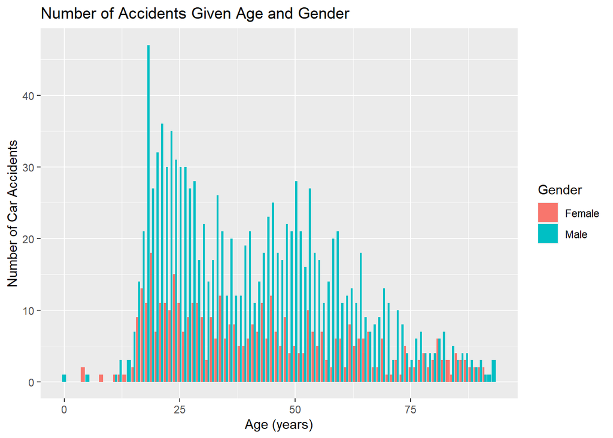

```r
ggplot(f1, aes(x=Age, y = count, fill = Gender)) + geom_bar(stat="identity", position = "dodge") + xlab("Age (years)") + ylab("Number of Car Accidents") + ggtitle("Number of Accidents Given Age and Gender")
```

```r
data2$dates <- as.Date(data2$'Crash Date', "%m/%d/%y")
temp <- data2
temp$weekday <- weekdays(temp$dates)
temp <- temp

temp$group1 <- ifelse(temp$Age < 41, "Under35", "35andUp")
temp2 <- temp %>% group_by(weekday, Gender) %>% filter(group1 == "Under35") %>% summarize(N = n()) %>% arrange(desc(N))
temp3 <- temp %>% group_by(weekday, Gender) %>% filter(group1 == "35andUp") %>% summarize(N = n()) %>% arrange(desc(N))
```

## Accidents with Age and Gender

Below are two graphs that show the number of car accidents by day of the week among men and women. The first graph is for Under 41 years old and the second graph is for 41 and older. The average age of someone in an accident in this data set was 41 so that is why I choose to use that as my cutoff in determining the groups.

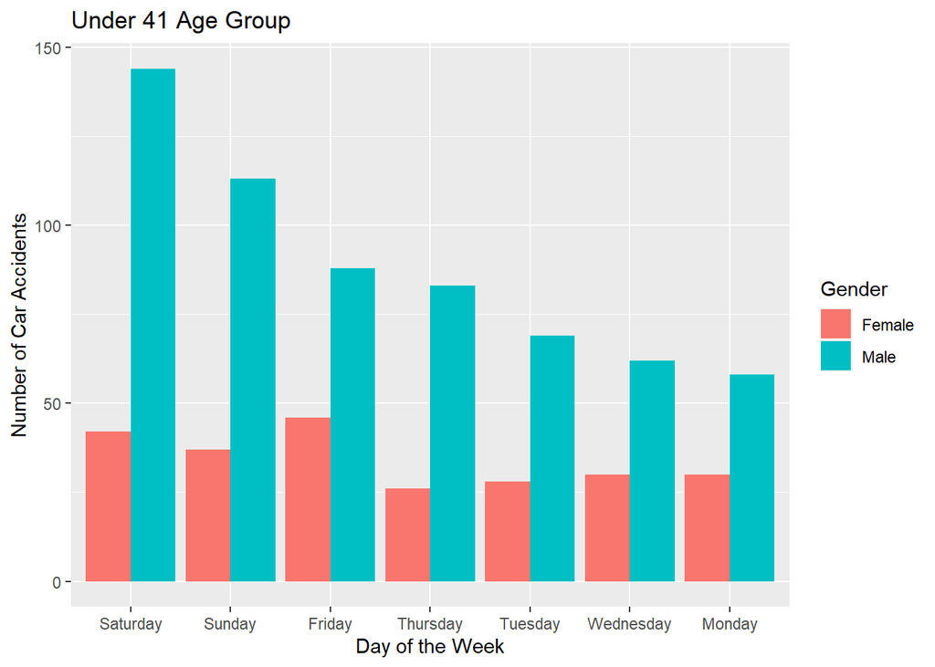

```r
ggplot(temp2, aes(x = reorder(weekday, -N), y = N, fill = Gender)) + geom_bar(stat = "identity", position = "dodge") + xlab("Day of the Week") + ylab("Number of Car Accidents") + ggtitle("Under 41 Age Group")
```

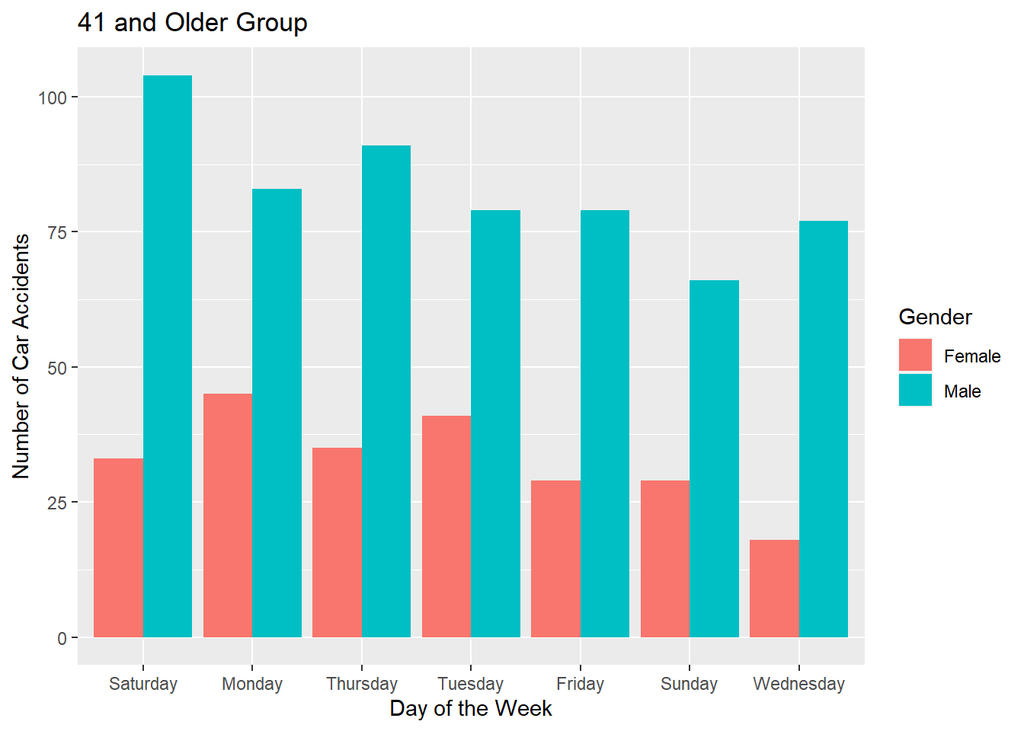

```r
ggplot(temp3, aes(x = reorder(weekday, -N), y = N, fill = Gender)) + geom_bar(stat = "identity", position = "dodge") + xlab("Day of the Week") + ylab("Number of Car Accidents") + ggtitle("41 and Older Group")
```